# CTCF genomewide analysis

Mathias

2025-11-14

#Aim In our reporer hopping experiments we saw that CBS-Sox2P aligned in the same orienation have a favored functional outcome. Therefore we wanted to check if there is a bias genomewide.

#Method I loaded all the annotated transcripts from UCSC and loaded the CTCF binding motifs that occur in the mm10 genome based on the most popular PWMs (961635) called sites with a pvalue <1e4. FIMO calls CTCF motifs with a default p-value threshold of 1×10⁻⁴, which is relatively permissive. Based on benchmarking against ENCODE SCREEN, a threshold of 1×10⁻⁶ gives ~80% true positive rate, so we restricted our analysis to motifs with p < 1×10⁻⁶.

Note that the FIMO tool detects CTCF binding sites using the 1e-4 p-value threshold by default (the more significant p-value corresponds to the more confidently detected CTCF motif). We found that this threshold may be too permissive. Using the ENCODE SCREEN database as ground truth, we found 1e-6 as the optimal threshold providing approximately 80% true positive rate. However, less significant CTCF motifs may be cell type-specific or have weaker CTCF binding and therefore be missed by conventional peak callers. If cell type-specific CTCF binding is of interest, we recommend exploring less significant CTCF sites.

Then I looked for CBS that are either in the same, oopposite or mixed orientation as the TSS, upstream or downstream of the TSS in a set window. I did this for different window sized and also calculated a metaplot representing the density of all CTCF sites in regards of distance of 10kb to the TSS.

# To-do’s

For now i am relying on CTCF motif predictions - repeat analysis with bound CTCF motifs from ChIP-seq for mESCs (we have our own data) - repeat to expressed genes in mESCs or different cell types and see if it holds true - Boundary vs non boundary: would be nice to stratify TSSs by “near TAD boundary” vs “intra-TAD” and ask if the orientation bias still holds up

# Install packages

```r
# BiocManager::install("AnnotationHub", update = FALSE)
# BiocManager::install("plyranges", update = FALSE)

library(GenomicRanges)
library(AnnotationHub)
library(plyranges)
library(knitr)
library(GenomicRanges)
library(rtracklayer)
library(gtools)
library(tidyverse)
```

```r
library(dplyr)
library(tidyr)
library(ggplot2)
library(ggbeeswarm)
library(Biostrings)
library(stringr)
library(readr)
library(knitr)
library(RColorBrewer)
library(purrr)
library(ggpubr)
library(cowplot)
library(biomaRt)
library(org.Mm.eg.db)
library(TxDb.Mmusculus.UCSC.mm10.knownGene)
library(gUtils)      # for gr.flipstrand
library(tibble)
```

# Paths & parameters

```r
#datatag
datetag = paste0("ME",format(Sys.time(), '%Y%m%d'))

# Prepare output
output_dir <- paste0("analysis",datetag)
dir.create(output_dir, showWarnings = FALSE)
```

```r
opts_chunk$set(fig.width = 20, fig.height = 8, cache = T,
               message = F, warning = F,
               dev=c('png', 'pdf'),
               fig.path = file.path(output_dir, "figures/"))
pdf.options(useDingbats = FALSE)
```

## Annotations

```r
Sox2_gene <- GRanges(seqnames = "chr3",
                    ranges = IRanges(start = 34649995,
                                     end = 34652461),
                    strand = "+")

## 1) Get Entrez ID for Nanog
nanog_entrez <- AnnotationDbi::select(
  org.Mm.eg.db,
  keys    = "Nanog",
  keytype = "SYMBOL",
  columns = "ENTREZID"
)$ENTREZID

## 2) Get all genes from TxDb and subset to Nanog
genes_txdb <- genes(TxDb.Mmusculus.UCSC.mm10.knownGene)

Nanog_gene <- genes_txdb[mcols(genes_txdb)$gene_id == nanog_entrez]
Nanog_gene
```

```
## GRanges object with 1 range and 1 metadata column:
##         seqnames              ranges strand |     gene_id
##            <Rle>           <IRanges>  <Rle> | <character>
##   71950     chr6 122707489-122714633      + |       71950
##   -------
##   seqinfo: 66 sequences (1 circular) from mm10 genome
```

# Load data

So every transcript gets a TSS. That means: Genes with many isoforms get many TSSs, and so more weight in all counts and metaplots. The analysis is per transcript.

```r
# TSSs (TxDb knownGene)
TSSs_all_transcripts <- resize(transcripts(TxDb.Mmusculus.UCSC.mm10.knownGene), width = 1, fix = "start")
TSSs_regular_chr <- keepStandardChromosomes(TSSs_all_transcripts, pruning.mode = "coarse")
```

```r
ah <- AnnotationHub()
```

[output not shown]

```r
query_data <- subset(ah, preparerclass == "CTCF")
# Explore the AnnotationHub object
query_data
```

```
## AnnotationHub with 51 records
## # snapshotDate(): 2024-10-28
## # $dataprovider: JASPAR 2022, CTCFBSDB 2.0, SwissRegulon, Jolma 2013, HOCOMO...
## # $species: Homo sapiens, Mus musculus
## # $rdataclass: GRanges
## # additional mcols(): taxonomyid, genome, description,
## #   coordinate_1_based, maintainer, rdatadateadded, preparerclass, tags,
## #   rdatapath, sourceurl, sourcetype
## # retrieve records with, e.g., 'object[["AH104716"]]'
##
##              title
##   AH104716 | T2T.CIS_BP_2.00_Homo_sapiens.RData
##   AH104717 | T2T.CTCFBSDB_PWM.RData
##   AH104718 | T2T.HOCOMOCOv11_core_HUMAN_mono_meme_format.RData
##   AH104719 | T2T.JASPAR2022_CORE_vertebrates_non_redundant_v2.RData
##   AH104720 | T2T.Jolma2013.RData
##   ...        ...
##   AH104762 | mm9.JASPAR2022_CORE_vertebrates_non_redundant_v2.RData
##   AH104763 | mm9.Jolma2013.RData
##   AH104764 | mm9.MA0139.1.RData
##   AH104765 | mm9.SwissRegulon_human_and_mouse.RData
##   AH104766 | mm8.CTCFBSDB.CTCF_predicted_mouse.RData
```

```r
subset(query_data, species == "Homo sapiens" &
                   genome == "hg38" &
                   dataprovider == "JASPAR 2022")
```

```
## AnnotationHub with 2 records
## # snapshotDate(): 2024-10-28
## # $dataprovider: JASPAR 2022
## # $species: Homo sapiens
## # $rdataclass: GRanges
## # additional mcols(): taxonomyid, genome, description,
## #   coordinate_1_based, maintainer, rdatadateadded, preparerclass, tags,
## #   rdatapath, sourceurl, sourcetype
## # retrieve records with, e.g., 'object[["AH104727"]]'
##
##              title
##   AH104727 | hg38.JASPAR2022_CORE_vertebrates_non_redundant_v2.RData
##   AH104729 | hg38.MA0139.1.RData
```

```r
subset(query_data, species == "Mus musculus" &
         genome == "mm10" &
         dataprovider == "JASPAR 2022")
```

```
## AnnotationHub with 2 records
## # snapshotDate(): 2024-10-28
## # $dataprovider: JASPAR 2022
## # $species: Mus musculus
## # $rdataclass: GRanges
## # additional mcols(): taxonomyid, genome, description,
## #   coordinate_1_based, maintainer, rdatadateadded, preparerclass, tags,
## #   rdatapath, sourceurl, sourcetype
## # retrieve records with, e.g., 'object[["AH104753"]]'
##
##              title
##   AH104753 | mm10.JASPAR2022_CORE_vertebrates_non_redundant_v2.RData
##   AH104755 | mm10.MA0139.1.RData
```

```r
# mm10 JASPAR2022_CORE_vertebrates_non_redundant_v2
CTCF_mm10_all <- query_data[["AH104753"]]

# mm10 using the most popular CTCF PWM
CTCF_mm10 <- query_data[["AH104755"]]

# Sanity: strands present?
table(strand(CTCF_mm10))
```

```
##
##      +      -      *
## 480877 480758      0
```

```r
table(strand(TSSs_regular_chr))[c("+","-")]
```

```
##
##     +     -
## 71759 70592
```

# Sort GRanges object and keep standard chromosomes

```r
CTCF_mm10_all <- CTCF_mm10_all %>% keepStandardChromosomes() %>% sort()
CTCF_mm10 <- CTCF_mm10 %>% keepStandardChromosomes() %>% sort()
```

# Save the data as bed file to manually check

```r
# Note that rtracklayer::import and rtracklayer::export perform unexplained
# start coordinate conversion, likely related to 0- and 1-based coordinate
# system. We recommend converting GRanges to a data frame and save tab-separated

# setwd("/DATA/usr/m.eder/projects/Tests/Genome_wide_CTCF_TSS_bias/")
#
# write.table(CTCF_mm10_all %>% sort() %>% as.data.frame(),
#             file = "CTCF_mm10_all.bed",
#             sep = "\t", row.names = FALSE, col.names = FALSE, quote = FALSE)
#
# write.table(CTCF_mm10 %>% sort() %>% as.data.frame(),
#             file = "CTCF_mm10.bed",
#             sep = "\t", row.names = FALSE, col.names = FALSE, quote = FALSE)
```

# Filter CTCF sites more stringently based on motif cutoff

```r
# Check length before filtering
print(paste("Number of CTCF motifs at the default 1e-4 threshold:", length(CTCF_mm10)))
```

```
## [1] "Number of CTCF motifs at the default 1e-4 threshold: 961635"
```

[output not shown]

```r
# Filter and check length after filtering
CTCF_mm10_filtered <- CTCF_mm10 %>% plyranges::filter(pvalue < 1e-6)
print(paste("Number of CTCF motifs at the 1e-6 threshold:", length(CTCF_mm10_filtered)))
```

```
## [1] "Number of CTCF motifs at the 1e-6 threshold: 32188"
```

[output not shown]

```r
# Similarly, filter
CTCF_mm10_all_filtered <- CTCF_mm10_all %>% plyranges::filter(pvalue < 1e-6)
print(paste("Number of CTCF motifs at the 1e-6 threshold:", length(CTCF_mm10_all_filtered)))
```

```
## [1] "Number of CTCF motifs at the 1e-6 threshold: 109363"
```

```r
# Proportion of overlapping enrtries
tmp <- findOverlaps(CTCF_mm10_all, CTCF_mm10_all)
ov_counts <- table(queryHits(tmp))
frac_with_neighbor <- mean(ov_counts > 1)
frac_with_neighbor
```

```
## [1] 0.4137338
```

[output not shown]

```r
tmp <- findOverlaps(CTCF_mm10, CTCF_mm10)
ov_counts <- table(queryHits(tmp))
frac_with_neighbor <- mean(ov_counts > 1)
frac_with_neighbor
```

```
## [1] 0.02605042
```

[output not shown]

# Unanimity-aware per-TSS classification

upstream/downstream relative to transcription direction

```r
# the classifier makes a decision based on TSS, if there are 2 in same and 3 in opposite it will get into the mixed bag

classify_ctcf_by_orientation <- function(TSSs, CTCF, window_size = 2500) {
  upstream_region   <- promoters(TSSs, upstream = window_size, downstream = 0)
  downstream_region <- promoters(TSSs, upstream = 0, downstream = window_size)

  classify_region <- function(region_gr, region_label) {
    # Count same- and opposite-orientation overlaps separately
    hits_same <- findOverlaps(CTCF, region_gr,                  ignore.strand = FALSE)
    hits_opp  <- findOverlaps(CTCF, gr.flipstrand(region_gr),   ignore.strand = FALSE)

    df_same <- tibble(tss_ix = subjectHits(hits_same)) %>% count(tss_ix, name = "n_same")
    df_opp  <- tibble(tss_ix = subjectHits(hits_opp))  %>% count(tss_ix, name = "n_opp")

    df <- full_join(df_same, df_opp, by = "tss_ix") %>%
      mutate(
        n_same = replace_na(n_same, 0L),
        n_opp  = replace_na(n_opp,  0L),
        region = region_label,
        class  = case_when(
          n_same > 0 & n_opp == 0 ~ "all_same",
          n_opp  > 0 & n_same == 0 ~ "all_opposite",
          n_same > 0 & n_opp  > 0 ~ "mixed",
          TRUE                    ~ "none"
        )
      )

    # Ensure every TSS is represented
    tibble(tss_ix = seq_along(region_gr)) %>%
      left_join(df, by = "tss_ix") %>%
      mutate(
        region = region_label,
        n_same = replace_na(n_same, 0L),
        n_opp  = replace_na(n_opp,  0L),
        class  = replace_na(class,  "none")
      )
  }

  bind_rows(
    classify_region(upstream_region,   "upstream"),
    classify_region(downstream_region, "downstream")
  )
}

# Run once at 2.5 kb
res_class <- classify_ctcf_by_orientation(TSSs_regular_chr, CTCF_mm10_all, window_size = 2500)
res_summary <- res_class %>% count(region, class, name = "n_TSS") %>% arrange(region, class)
res_summary
```

```
## # A tibble: 8 × 3
##   region     class        n_TSS
##   <chr>      <chr>        <int>
## 1 downstream all_opposite 18359
## 2 downstream all_same     18424
## 3 downstream mixed        93925
## 4 downstream none         11643
## 5 upstream   all_opposite 19172
## 6 upstream   all_same     20095
## 7 upstream   mixed        90300
## 8 upstream   none         12784
```

# Implement in anlysis

## Window-size sweep + stacked fractions

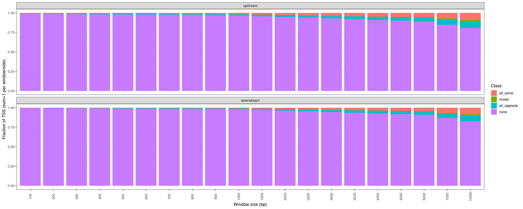

```r
window_grid <- c(seq(100, 900, 100), seq(1000, 5000, 500), seq(7500, 10000, 2500))

res_all <- map_df(window_grid, function(w) {
  tmp <- classify_ctcf_by_orientation(TSSs_regular_chr, CTCF_mm10_filtered, window_size = w)
  total_tss <- length(TSSs_regular_chr)
  tmp %>% count(region, class, name = "n_TSS") %>%
    mutate(windowsize = w, frac = n_TSS / total_tss)
})

res_all <- res_all %>%
  mutate(
    region = factor(region, levels = c("upstream","downstream")),
    class  = factor(class,  levels = c("all_same","mixed","all_opposite","none"))
  )

# Figure S4A
p_frac <- ggplot(res_all, aes(x = factor(windowsize), y = frac, fill = class)) +
  geom_col(position = "fill") +
  facet_wrap(~ region, ncol = 1) +
  labs(x = "Window size (bp)", y = "Fraction of TSS (sum=1 per window/side)", fill = "Class") +
  theme_bw(base_size = 12) +
  theme(axis.text.x = element_text(angle = 90, vjust = 0.5))
p_frac
```

```r
#ggsave(file.path(output_dir, "ctcf_unanimity_fractions_by_window.pdf"), p_frac, width = 12, height = 6)
```

## Figure 4B

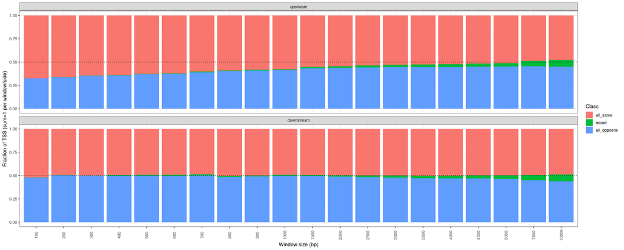

```r
# Figure 4B
res_all %>% filter(class != "none") %>%
 ggplot(aes(x = factor(windowsize), y = frac, fill = class)) +
  geom_col(position = "fill") +
  facet_wrap(~ region, ncol = 1) +
  geom_hline(yintercept = 0.5, col = "black", linetype = "dotted") +
  labs(x = "Window size (bp)", y = "Fraction of TSS (sum=1 per window/side)", fill = "Class") +
  theme_bw(base_size = 12) +
  theme(axis.text.x = element_text(angle = 90, vjust = 0.5))
```

## Figure S4B

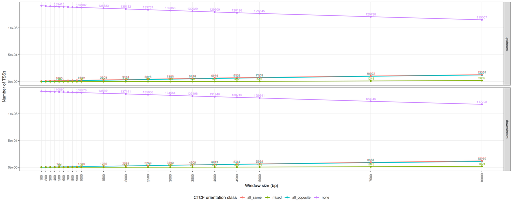

```r
#Different way of plotting
res_counts <- res_all %>%
  mutate(
    region = factor(region, levels = c("upstream","downstream")),
    class  = factor(class,  levels = c("all_same","mixed","all_opposite","none"))
  )

# Figure S4B
# label a subset of x ticks for readability (every 1000 bp + the max)
label_df <- res_counts %>%
  filter(windowsize %% 500 == 0 | windowsize == max(windowsize)) #filtering for everything that is 1000/x = 0 (multiple of 1000s)

res_counts %>%
ggplot(aes(x = windowsize, y = n_TSS, color = class)) +
  geom_line(linewidth = 0.8) +
  geom_point(size = 1.8) +
  geom_text(
    data = label_df,
    aes(label = n_TSS),
    vjust = -0.6, size = 3, show.legend = FALSE
  ) +
  facet_grid(region ~ ., scales = "free_y") +
  scale_x_continuous(breaks = sort(unique(res_counts$windowsize))) +
  labs(x = "Window size (bp)", y = "Number of TSSs", color = "CTCF orientation class") +
  theme_bw(base_size = 12) +
  theme(
    panel.grid.minor = element_blank(),
    axis.text.x = element_text(angle = 90, vjust = 0.5)
  ) +
  theme(legend.position = "bottom")
```

## Figure 4C

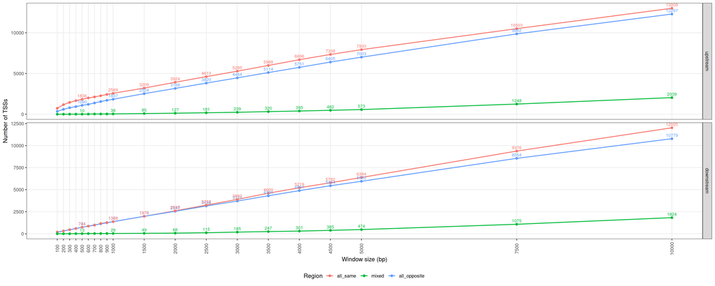

```r
res_counts %>% filter(class != "none") %>%
ggplot(aes(x = windowsize, y = n_TSS, color = class)) +
  geom_line(linewidth = 0.8) +
  geom_point(size = 1.8) +
  geom_text(
    data = label_df %>% filter(class != "none"),
    aes(label = n_TSS),
    vjust = -0.6, size = 3, show.legend = FALSE
  ) +
  facet_grid(region ~ ., scales = "free_y") +
  scale_x_continuous(breaks = sort(unique(res_counts$windowsize))) +
  labs(x = "Window size (bp)", y = "Number of TSSs", color = "Region") +
  theme_bw(base_size = 12) +
  theme(
    panel.grid.minor = element_blank(),
    axis.text.x = element_text(angle = 90, vjust = 0.5)
  ) +
  theme(legend.position = "bottom")
```

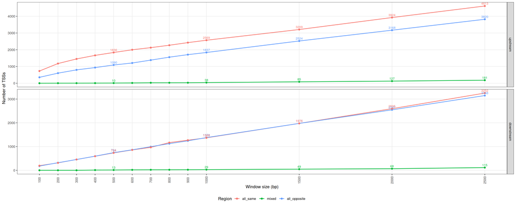

```r
res_counts %>% filter(class != "none" & windowsize <= 2500) %>%
ggplot(aes(x = windowsize, y = n_TSS, color = class)) +
  geom_line(linewidth = 0.8) +
  geom_point(size = 1.8) +
  geom_text(
    data = label_df %>% filter(class != "none" & windowsize <= 2500),
    aes(label = n_TSS),
    vjust = -0.6, size = 3, show.legend = FALSE
  ) +
  facet_grid(region ~ ., scales = "free_y") +
  scale_x_continuous(breaks = sort(unique(res_counts$windowsize))) +
  labs(x = "Window size (bp)", y = "Number of TSSs", color = "Region") +
  theme_bw(base_size = 12) +
  theme(
    panel.grid.minor = element_blank(),
    axis.text.x = element_text(angle = 90, vjust = 0.5)
  ) +
  theme(legend.position = "bottom")
```

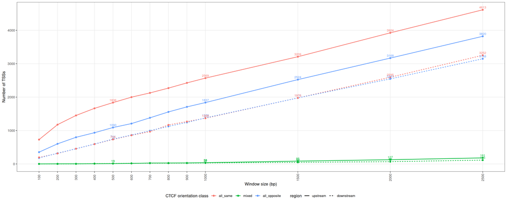

```r
res_counts %>% filter(class != "none" & windowsize <= 2500) %>%
ggplot(aes(x = windowsize, y = n_TSS, color = class, linetype = region)) +
  geom_line(linewidth = 0.8) +
  geom_point(size = 1.8) +
  geom_text(
    data = label_df %>% filter(class != "none" & windowsize <= 2500),
    aes(label = n_TSS),
    vjust = -0.6, size = 3, show.legend = FALSE
  ) +
  #facet_grid(region ~ ., scales = "free_y") +
  scale_x_continuous(breaks = sort(unique(res_counts$windowsize))) +
  labs(x = "Window size (bp)", y = "Number of TSSs", color = "CTCF orientation class") +
  theme_bw(base_size = 12) +
  theme(
    panel.grid.minor = element_blank(),
    axis.text.x = element_text(angle = 90, vjust = 0.5)
  ) +
  theme(legend.position = "bottom")
```

```r
######### orientation specific ###########
# TSS-centered (±15 kb) with proper same/opposite classes
meta_window <- 15000
TSS_meta_regions <- resize(TSSs_regular_chr, width = 2*meta_window + 1, fix = "center")

# make the TSS windows unstranded for overlap purposes
TSS_meta_unstr <- TSS_meta_regions
strand(TSS_meta_unstr) <- "*"

midpoint <- function(gr) (start(gr) + end(gr)) %/% 2L

# include all CTCFs near TSS windows regardless of strand
CTCF_near_TSS <- subsetByOverlaps(CTCF_mm10_filtered, TSS_meta_unstr, ignore.strand = TRUE)

# find overlaps without strand constraint
ov1 <- findOverlaps(CTCF_near_TSS, TSS_meta_unstr, ignore.strand = TRUE)

rel_pos_df_TSS <- tibble(
  ctcf_ix     = queryHits(ov1),
  tss_ix      = subjectHits(ov1),
  ctcf_pos    = midpoint(CTCF_near_TSS)[ctcf_ix],
  tss_pos     = start(TSSs_regular_chr)[tss_ix],
  ctcf_strand = as.character(strand(CTCF_near_TSS))[ctcf_ix],
  tss_strand  = as.character(strand(TSSs_regular_chr))[tss_ix]
) %>%
  # (optional) drop unknown CTCF strands
  filter(ctcf_strand %in% c("+","-")) %>%
  mutate(
    # distance from TSS perspective: <0 upstream, >0 downstream
    rel_pos = if_else(tss_strand == "+", ctcf_pos - tss_pos, tss_pos - ctcf_pos),
    orientation_match = if_else(ctcf_strand == tss_strand, "same", "opposite")
  )
```

## Get density stats

```r
rel_pos_df_TSS %>%
  dplyr::group_by(orientation_match) %>%
  dplyr::summarise(count = dplyr::n(),
                   mean = mean(rel_pos),
                   median = median(rel_pos))
```

```
## # A tibble: 2 × 4
##   orientation_match count  mean median
##   <chr>             <int> <dbl>  <int>
## 1 opposite          45271 -351.   -641
## 2 same              47659  259.    -53
```

```r
dens_df <- rel_pos_df_TSS %>%
  group_by(orientation_match) %>%
  do({
    d <- density(.$rel_pos, bw = 250, na.rm = TRUE)
    tibble(rel_pos = d$x, density = d$y)
  }) %>%
  ungroup()

modes <- dens_df %>%
  group_by(orientation_match) %>%
  slice_max(order_by = density, n = 1, with_ties = FALSE) %>%
  rename(mode_rel_pos = rel_pos, max_density = density)

modes
```

```
## # A tibble: 2 × 3
## # Groups:   orientation_match [2]
##   orientation_match mode_rel_pos max_density
##   <chr>                    <dbl>       <dbl>
## 1 opposite                 -154.   0.0000439
## 2 same                     -154.   0.0000649
```

```r
modes %>%
  mutate(mode_rel_pos_kb = mode_rel_pos / 1000) %>%
  kable()
```

| orientation_match | mode_rel_pos | max_density | mode_rel_pos_kb |
| --- | --- | --- | --- |
| opposite | -154.1977 | 4.39e-05 | -0.1541977 |
| same | -153.6928 | 6.49e-05 | -0.1536928 |

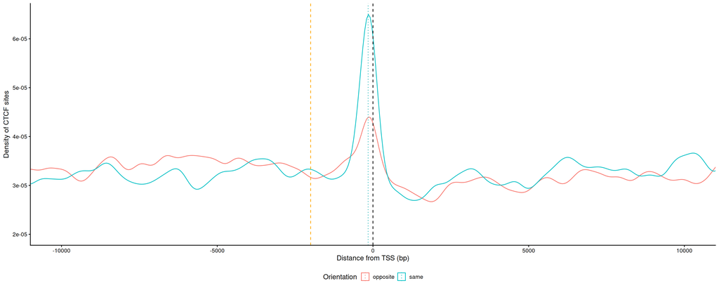

```r
## with number of density written
ggplot(rel_pos_df_TSS, aes(x = rel_pos, color = orientation_match)) +
  geom_density(bw = 250) +
  geom_vline(xintercept = 0, linetype = "dashed") +
  geom_vline(
    data = modes,
    aes(xintercept = mode_rel_pos, color = orientation_match),
    linetype = "dotted"
  ) +
  geom_vline(xintercept = -2000, linetype = "dashed", col = "orange") +
  geom_text(
    data = modes,
    aes(x = mode_rel_pos, y = 0,
        label = round(mode_rel_pos)),    # label in bp
    angle = 90, vjust = -0.5, hjust = -5,
    show.legend = FALSE
  ) +
  coord_cartesian(ylim = c(2e-5, NA), xlim = c(-1e4, 1e4)) +  # <-- crop off the flat bottom
  labs(
    x = "Distance from TSS (bp)",
    y = "Density of CTCF sites",
    color = "Orientation"
  ) +
  theme_classic(base_size = 14) +
  theme(legend.position = "bottom")
```